# Funciones perdiódicas

Kenneth Roy Cabrera Torres

Viernes, 5 de mayo de 2017

## Funciones periódicas

### Función seno()

```r
x <- seq(0, 16*pi, pi/24)
senox <- sin(x)
```

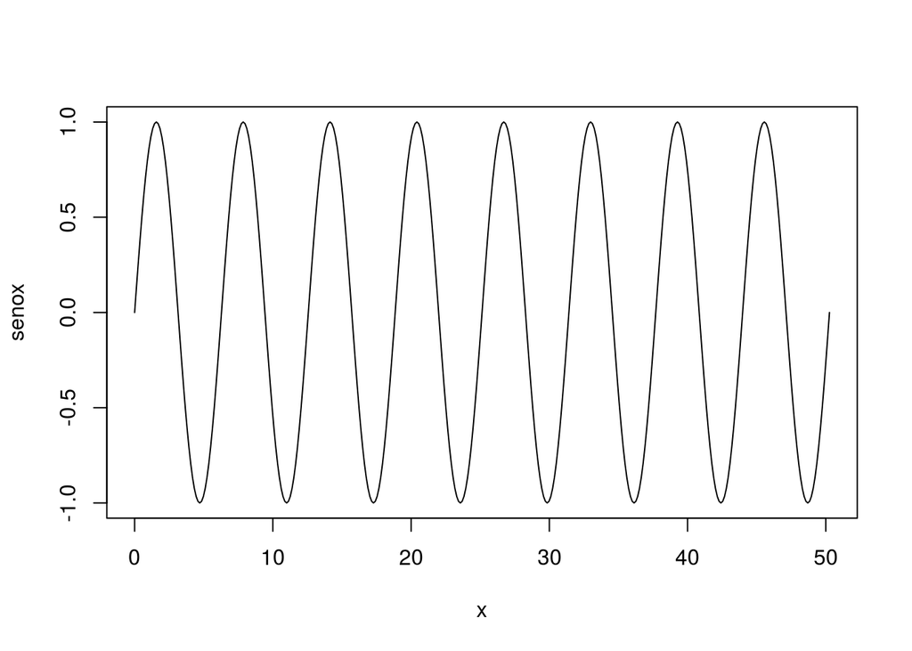

```r
plot(x, senox, type = "l")
```

### Función coseno()

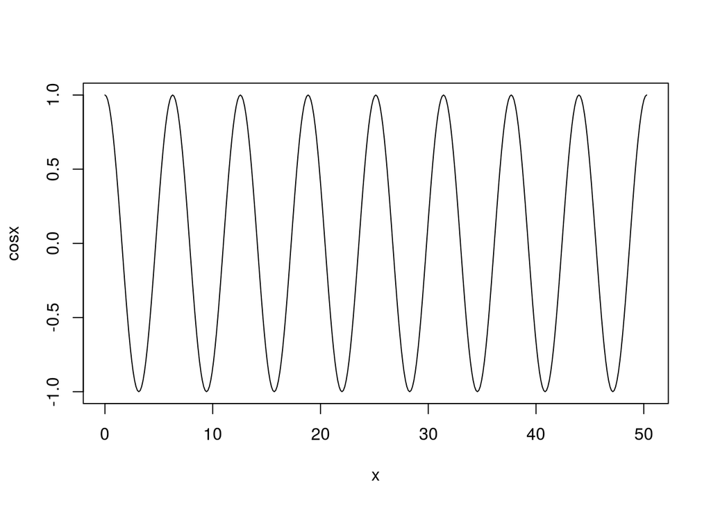

```r
cosx <- cos(x)
plot(x, cosx, type = "l")
```

## Función periódica con amplitud y frecuencia diferente

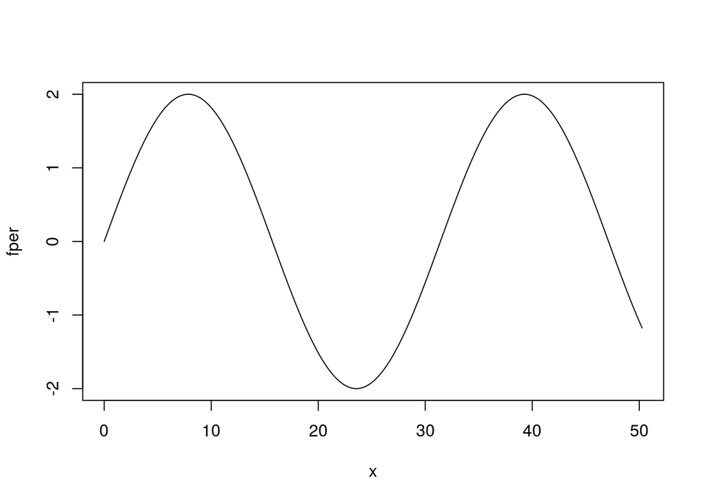

```r
fper <- 2*sin(x/5)
plot(x, fper, type = "l")
```

## Composición de funciones periódicas

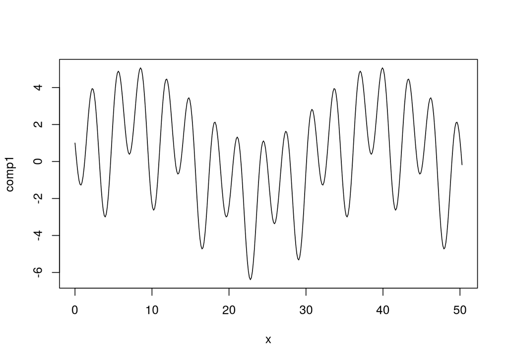

```r
comp1 <- senox + cosx + fper + 3* sin(2*x + pi)
plot(x, comp1, type = "l")
```

## Ejercicio individual

Dada una base de datos en donde se especifice por filas cuatro parámetros, funcion: sen o cos, A: amplitud, factor_frec: factor de frecuencia y despl: desplazamiento.

Constuir una función que tenga como entrada los valores de los ángulos ($x$), la base de datos anteriormente definida y como salida el resultado de la composición de todas las definiciones de la base de datos.

Por ejemplo en el caso presentado la base de datos sería la siguiente:

```r
base1 <- read.csv2("taller1.csv")
base1
```

[output not shown]

La función deberá generar los valores de $y$ (comp1) de la función compuesta:

```
comp1 <- funcion_taller(x, base1)
```

```r
comp1
```

```
##   [1]  1.00000000  0.39786781 -0.17058322 -0.65783919 -1.02299388
##   [6] -1.23461033 -1.27291751 -1.13119166 -0.81622743 -0.34786665
##  [11]  0.24238296  0.91354461  1.61803399  2.30498952  2.92384268
##  [16]  3.42788331  3.77757490  3.94339158  3.90798100  3.66750309
##  [21]  3.23205081  2.62512137  1.88217129  1.04835094  0.17557050
##  [26] -0.68090533 -1.46610409 -2.12898721 -2.62584040 -2.92318310
##  [31] -3.00000000 -2.84914351 -2.47781196 -1.90707138 -1.17045295
##  [36] -0.31172151  0.61803399  1.56379084  2.47023435  3.28540457
##  [41]  3.96410162  4.47081979  4.78201305  4.88753996  4.79119253
##  [46]  4.51027551  4.07426763  3.52265879  2.90211303  2.26315339
##  [51]  1.65659652  1.12998246  0.72424439  0.47084711  0.38959024
##  [56]  0.48722701  0.75699298  1.17907729  1.72200394  2.34482857
##  [61]  3.00000000  3.63669045  4.20436585  4.65635111  4.95314541
##  [66]  5.06525911  4.97537668  4.67969538  4.18834601  3.52486408
##  [71]  2.72474487  1.83317794  0.90211303 -0.01314521 -0.85758402
```

[output cut: 62 more lines]

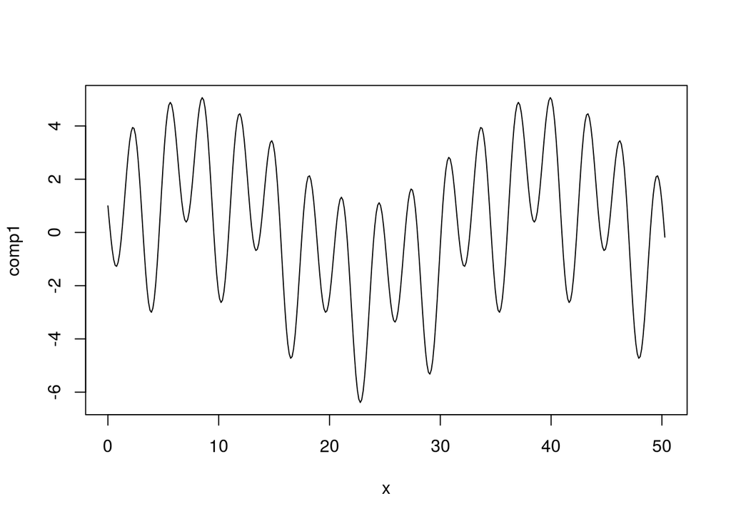

```r
plot(x, comp1, type = "l")
```

## Fecha de entrega

Miércoles, 10 de mayo de 2017 antes de las 23:59 hora de Colombia al correo krcabrer@unal.edu.co no olvidar escribir en asunto [ModuloR].

NO se admitiran FUNCIONES iguales (ni maquilladas).

Nota: La mejor función será la que tenga menos “if” y menos “for” posibles, y de ahí hacia atrás se calificará desde 5.0.

Documento de entrega:

- Archivo “html” sin códigos, en donde se explique el uso y ejemplos de la función construida.
- Archivo “Rmd” con el código de la función construida.